# Contract Termination

### Model 02C: Cost Ceiling and Competition

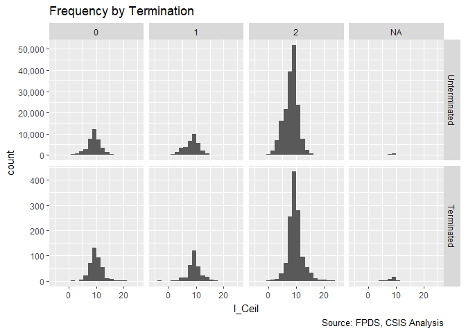

```r
#Frequency Plot
freq_continuous_term_plot(Term_smp,"l_Ceil","n_Comp")
```

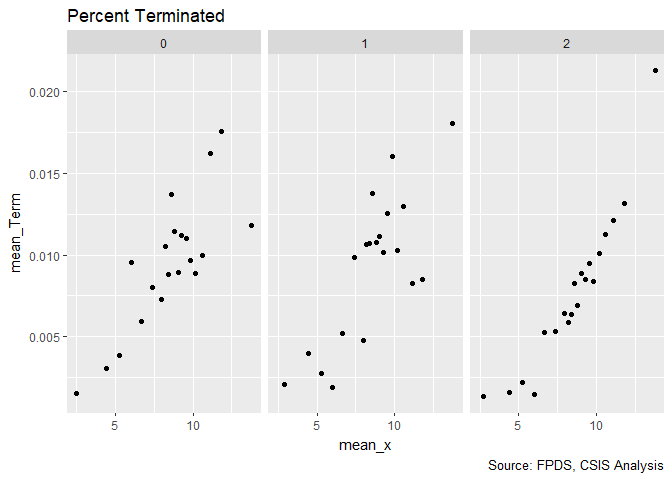

```r
#Plot the percent terminated across cost ceiling and competition
binned_percent_term_plot(Term_smp,"l_Ceil","n_Comp")
```

```r
#Create the model
Term_02C <- glm (data=Term_smp,
                 b_Term ~n_Comp + cl_Ceil + clsqr_Ceil + n_Comp:cl_Ceil, family=binomial(link="logit"))
display(Term_02C)
```

```
## glm(formula = b_Term ~ n_Comp + cl_Ceil + clsqr_Ceil + n_Comp:cl_Ceil,
##     family = binomial(link = "logit"), data = Term_smp)
##                coef.est coef.se
## (Intercept)    -4.62     0.05
## n_Comp         -0.19     0.03
## cl_Ceil         0.32     0.05
## clsqr_Ceil     -0.05     0.01
## n_Comp:cl_Ceil  0.18     0.03
## ---
##   n = 248258, k = 5
##   residual deviance = 22743.2, null deviance = 23346.1 (difference = 602.9)
```

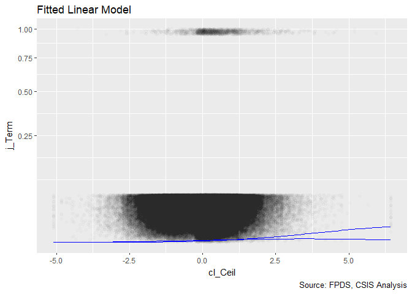

```r
Term_02C_curve<-function(x, Comp){invlogit(cbind(1,Comp,x,x^2,Comp*x) %*%  coef(Term_02C))}

#Competition Curves
fitted_term_model(Term_smp,"cl_Ceil") + stat_function(fun = Term_02C_curve,
                             args=list(Comp=0),color="blue")+
  stat_function(fun = Term_02C_curve,
                             args=list(Comp=2),color="blue")
```

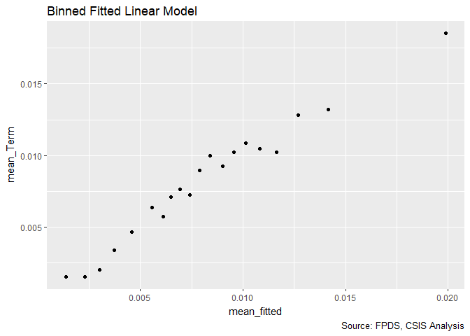

```r
#Plot the fitted values vs actual results
binned_fitted_versus_residuals(Term_02C)
```

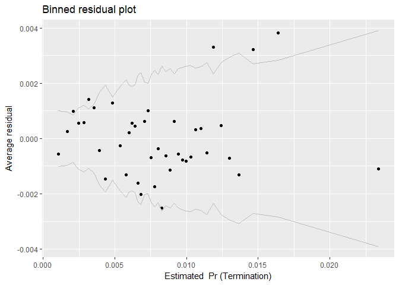

```r
#Plot residuals versus fitted
residuals_term_plot(Term_02C)+
  labs(x="Estimated  Pr (Termination)")
```

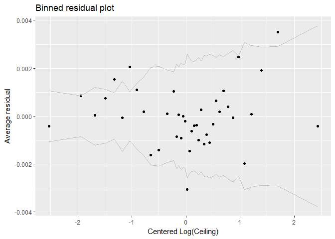

```r
residuals_term_plot(Term_02C,"cl_Ceil")+
  labs(x="Centered Log(Ceiling)")
```

The interaction went in the expected direction, but is surprisingly powerful. Competition heightens the importance of contract ceiling, and larger contract ceilings mitigate the importance of competition. The other powerful part of this interaction was the dramatic increase in the coefficient for competition and the comparative reduction in the correlation of ceiling.

### Model 02D: Maximum Duration

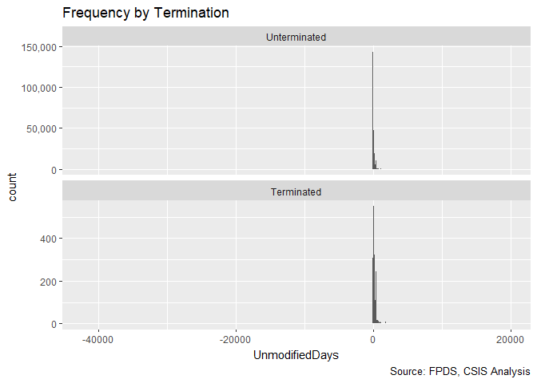

```r
#Frequency Plot for max duration
freq_continuous_term_plot(Term_smp,"UnmodifiedDays",
               bins=1000)
```

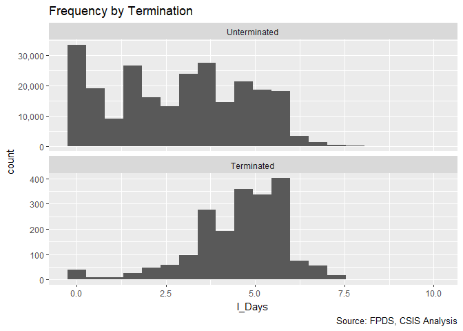

```r
#Frequency Plot for logged max duration
freq_continuous_term_plot(Term_smp,"l_Days")
```

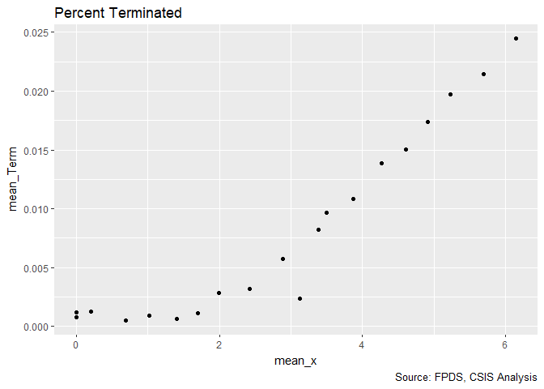

```r
#Percent Terminated Plot
binned_percent_term_plot(Term_smp,"l_Days")
```

```r
#Model
Term_02D <- glm (data=Term_smp,
                 b_Term ~n_Comp +
                   cl_Ceil + clsqr_Ceil + cl_Days + clsqr_Ceil +
                   n_Comp:cl_Ceil , family=binomial(link="logit"))
display(Term_02D)
```

```
## glm(formula = b_Term ~ n_Comp + cl_Ceil + clsqr_Ceil + cl_Days +
##     clsqr_Ceil + n_Comp:cl_Ceil, family = binomial(link = "logit"),
##     data = Term_smp)
##                coef.est coef.se
## (Intercept)    -5.35     0.06
## n_Comp          0.03     0.03
## cl_Ceil        -0.08     0.06
## clsqr_Ceil     -0.05     0.02
## cl_Days         1.04     0.03
## n_Comp:cl_Ceil  0.14     0.03
## ---
##   n = 246889, k = 6
##   residual deviance = 21138.7, null deviance = 22986.9 (difference = 1848.2)
```

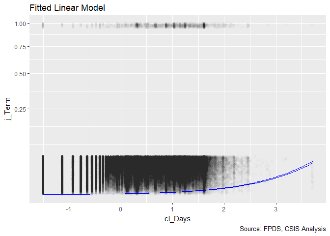

```r
Term_02D_curve<-function(x, Comp,Ceil){invlogit(cbind(1,Comp,Ceil,Ceil^2,x,Comp*Ceil) %*%  coef(Term_02D))}

#Competition Curves
fitted_term_model(Term_smp,"cl_Days") + stat_function(fun = Term_02D_curve,
                             args=list(Comp=0,Ceil=0),color="blue")+
  stat_function(fun = Term_02D_curve,
                             args=list(Comp=2,Ceil=0),color="blue")
```

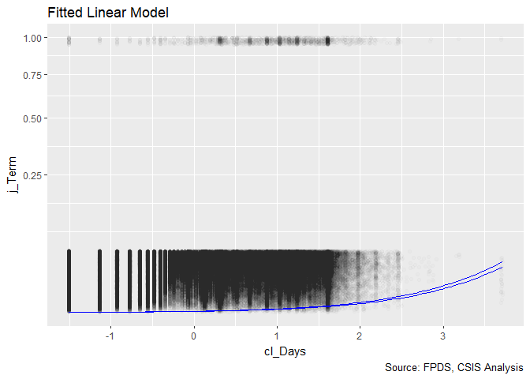

```r
#Ceiling Curves
fitted_term_model(Term_smp,"cl_Days") +  stat_function(fun = Term_02D_curve,
                             args=list(Comp=0,Ceil=0),color="blue")+
  stat_function(fun = Term_02D_curve,
                             args=list(Comp=0,Ceil=1),color="blue")
```

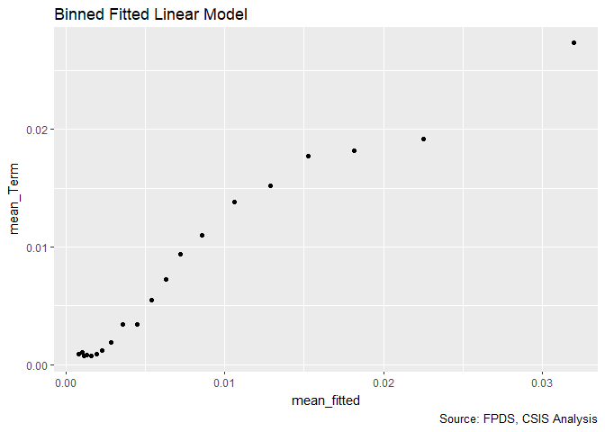

```r
#Plot the fitted values vs actual results
binned_fitted_versus_residuals(Term_02D)
```

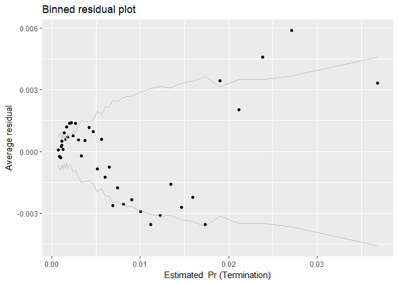

```r
#Plot residuals versus fitted
residuals_term_plot(Term_02D)+
  labs(x="Estimated  Pr (Termination)")
```

```r
# debug(binned.resids)
# residuals_term_plot(Term_02D,"cl_Days")+
  # labs(x="Centered Log(Ceiling)")
```

### Model 02E: Interation of Ceiling and Duration

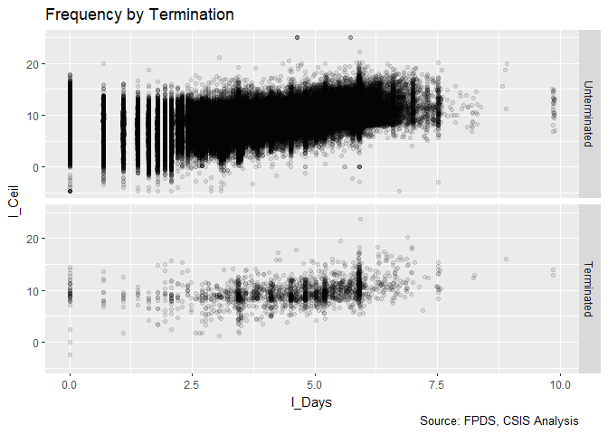

```r
#First a quick scatter plot for terminations by duration and ceiling
ggplot(data=subset(Term_smp,!is.na(l_Ceil)),
       aes(x=l_Days,y=l_Ceil))+geom_point(alpha=0.1)+facet_grid(Term~.)+
  labs(title="Frequency by Termination",
          caption="Source: FPDS, CSIS Analysis")
```

```r
#Create the model
Term_02E <- glm (data=Term_smp,
                 b_Term ~n_Comp +
                   cl_Ceil + clsqr_Ceil + cl_Days+
                   n_Comp:cl_Ceil  + cl_Ceil:cl_Days, family=binomial(link="logit"))
display(Term_02E)
```

```
## glm(formula = b_Term ~ n_Comp + cl_Ceil + clsqr_Ceil + cl_Days +
##     n_Comp:cl_Ceil + cl_Ceil:cl_Days, family = binomial(link = "logit"),
##     data = Term_smp)
##                 coef.est coef.se
## (Intercept)     -5.44     0.07
## n_Comp           0.05     0.03
## cl_Ceil          0.14     0.06
## clsqr_Ceil       0.02     0.02
## cl_Days          1.13     0.03
## n_Comp:cl_Ceil   0.10     0.03
## cl_Ceil:cl_Days -0.26     0.04
## ---
##   n = 246889, k = 7
##   residual deviance = 21089.0, null deviance = 22986.9 (difference = 1897.9)
```

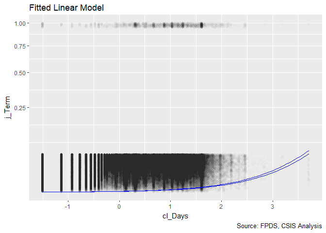

```r
Term_02E_curve<-function(x, Comp,Ceil){invlogit(
  cbind(1,Comp,Ceil,Ceil^2,x,
        Comp*Ceil,x*Ceil) %*%  coef(Term_02E))}



#Competition Curves
fitted_term_model(Term_smp,"cl_Days") + stat_function(fun = Term_02E_curve,
                             args=list(Comp=0,Ceil=0),color="blue")+
  stat_function(fun = Term_02E_curve,
                             args=list(Comp=2,Ceil=0),color="blue")
```

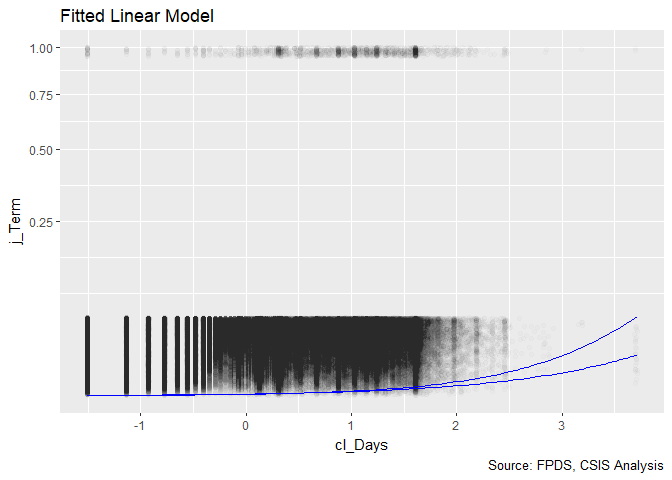

```r
#Ceiling Curves
fitted_term_model(Term_smp,"cl_Days") +  stat_function(fun = Term_02E_curve,
                             args=list(Comp=0,Ceil=0),color="blue")+
  stat_function(fun = Term_02E_curve,
                             args=list(Comp=0,Ceil=1),color="blue")
```

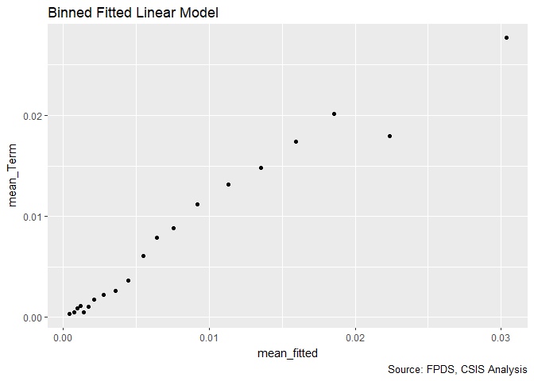

```r
#Plot the fitted values vs actual results
binned_fitted_versus_residuals(Term_02E)
```

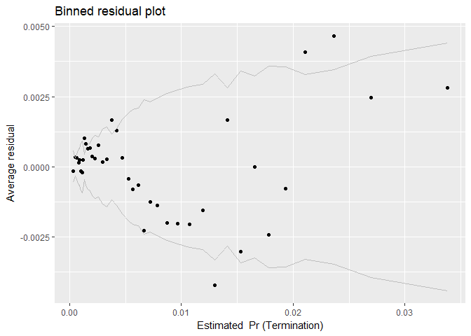

```r
#Plot residuals versus fitted
residuals_term_plot(Term_02E)+
  labs(x="Estimated  Pr (Termination)")
```

```r
# debug(binned.resids)
# residuals_term_plot(Term_02E,"cl_Days")+
  # labs(x="Centered Log(Ceiling)")
```

The interaction of ceiling and duration is correlated with a lower rate of termination, which is to say that when either factor is high, the other has less effect. Thus long contracts with fewer dollars or high ceiling contract with shorter durations are at higher risk than more balanced contracts. This interaction also restores the positive coefficient for ceiling and switches ceiling squared to positive. The residuals still show a pattern tht could be explained by an exponential. Examining that possibility will be the next step.

### Model 02F: Duration Squared

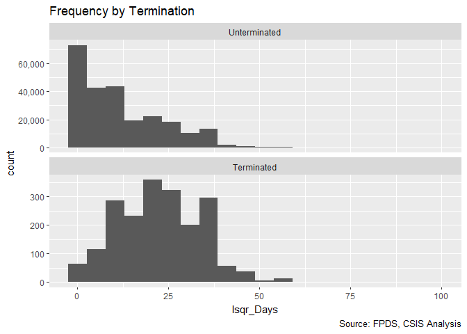

```r
Term_smp$clsqr_Days<-Term_smp$cl_Days^2
Term_smp$lsqr_Days<-Term_smp$l_Days^2


#Frequency Plot
freq_continuous_term_plot(Term_smp,"lsqr_Days")
```

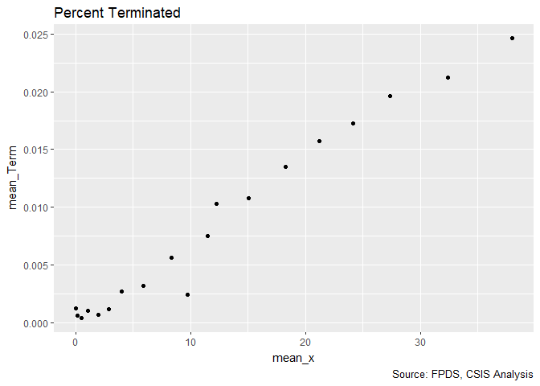

```r
#Percent Terminated Plot
binned_percent_term_plot(Term_smp,"lsqr_Days")
```

```r
#Create the model
Term_02F <- glm (data=Term_smp,
                 b_Term ~n_Comp +
                   cl_Ceil + clsqr_Ceil + cl_Days+ clsqr_Days +
                   n_Comp:cl_Ceil  + cl_Ceil:cl_Days, family=binomial(link="logit"))
display(Term_02F)
```

```
## glm(formula = b_Term ~ n_Comp + cl_Ceil + clsqr_Ceil + cl_Days +
##     clsqr_Days + n_Comp:cl_Ceil + cl_Ceil:cl_Days, family = binomial(link = "logit"),
##     data = Term_smp)
##                 coef.est coef.se
## (Intercept)     -5.38     0.07
## n_Comp           0.05     0.03
## cl_Ceil          0.11     0.07
## clsqr_Ceil       0.02     0.02
## cl_Days          1.24     0.05
## clsqr_Days      -0.11     0.03
## n_Comp:cl_Ceil   0.11     0.03
## cl_Ceil:cl_Days -0.22     0.04
## ---
##   n = 246889, k = 8
##   residual deviance = 21074.1, null deviance = 22986.9 (difference = 1912.9)
```

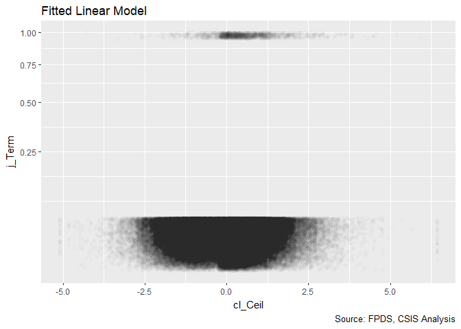

```r
Term_02F_curve<-function(x, Comp,Ceil){invlogit(
  cbind(1,Comp,Ceil,Ceil^2,x,x^2,
        Comp*Ceil,x*Ceil) %*%  coef(Term_02F))}

#Competition curves
fitted_term_model(Term_smp,"cl_Ceil") + stat_function(fun = Term_02F_curve,
                             args=list(Comp=0),color="blue")+
  stat_function(fun = Term_02F_curve,
                             args=list(Comp=2),color="blue")
```

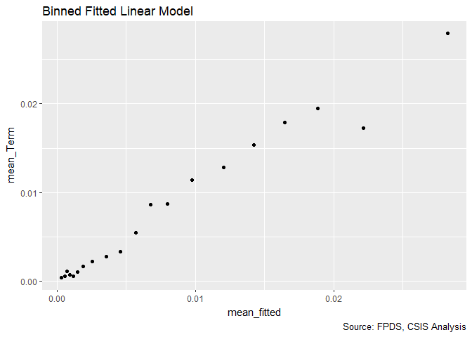

```r
#Plot the fitted values vs actual results
binned_fitted_versus_residuals(Term_02F)
```

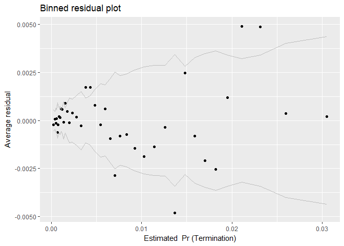

```r
#Plot residuals versus fitted
residuals_term_plot(Term_02F)+
  labs(x="Estimated  Pr (Termination)")
```

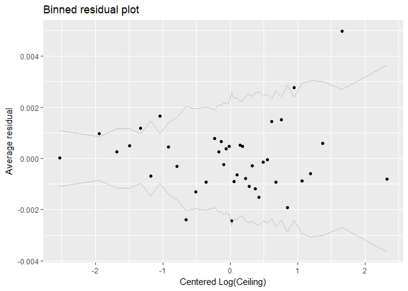

```r
# residuals_term_plot(Term_02F,"cl_days")+
#   labs(x="Centered Log(Days)")


residuals_term_plot(Term_02F,"cl_Ceil")+
  labs(x="Centered Log(Ceiling)")
```

Adding log(initial duration)^2 does seem to address the troubling pattern present in the residuals, namely the parabolic curve and the large number of data bins falling outside of the 95% confidence interval. Both of the ceiling coefficients remain positive but they are no longer coefficient. The next step is to see whether log(initial cost ceiling)^2 is still useful in this model now that the square of duration is included.

### Model 02G: Testing the removal of Ceiling^2

```r
#Create the model
Term_02G <- glm (data=Term_smp,
                 b_Term ~n_Comp +
                   cl_Ceil + cl_Days+ clsqr_Days +
                   n_Comp:cl_Ceil  + cl_Ceil:cl_Days, family=binomial(link="logit"))
display(Term_02G)
```

```
## glm(formula = b_Term ~ n_Comp + cl_Ceil + cl_Days + clsqr_Days +
##     n_Comp:cl_Ceil + cl_Ceil:cl_Days, family = binomial(link = "logit"),
##     data = Term_smp)
##                 coef.est coef.se
## (Intercept)     -5.36     0.07
## n_Comp           0.04     0.03
## cl_Ceil          0.10     0.07
## cl_Days          1.23     0.05
## clsqr_Days      -0.11     0.03
## n_Comp:cl_Ceil   0.11     0.03
## cl_Ceil:cl_Days -0.20     0.03
## ---
##   n = 246889, k = 7
##   residual deviance = 21075.8, null deviance = 22986.9 (difference = 1911.1)
```

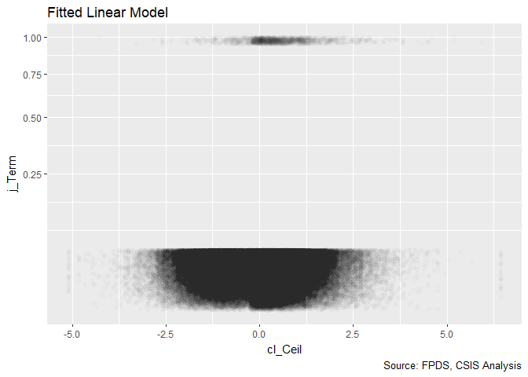

```r
Term_02G_curve<-function(x, Comp,Ceil){invlogit(
  cbind(1,Comp,Ceil,x,x^2,
        Comp*Ceil,x*Ceil) %*%  coef(Term_02E))}

#Competition curves
fitted_term_model(Term_smp,"cl_Ceil") + stat_function(fun = Term_02G_curve,
                             args=list(Comp=0),color="blue")+
  stat_function(fun = Term_02G_curve,
                             args=list(Comp=2),color="blue")
```

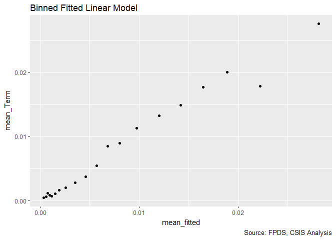

```r
#Plot the fitted values vs actual results
binned_fitted_versus_residuals(Term_02G)
```

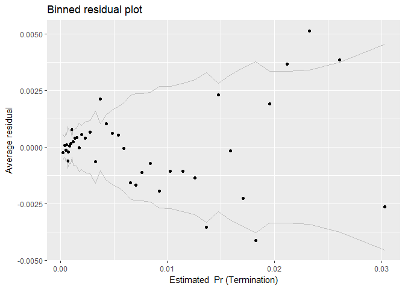

```r
#Plot residuals versus fitted
residuals_term_plot(Term_02G)+
  labs(x="Estimated  Pr (Termination)")
```

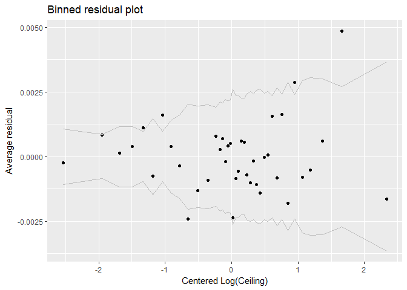

```r
residuals_term_plot(Term_02G,"cl_Ceil")+
  labs(x="Centered Log(Ceiling)")
```

While the effect on the residual deviance is fairly minor, it does still appear that the ceiling^2 does reduce the incidence of non-linear patterns in the residuals. So for now we will be leaving it in.

### Model 02H: Interaction of Duration and Competition

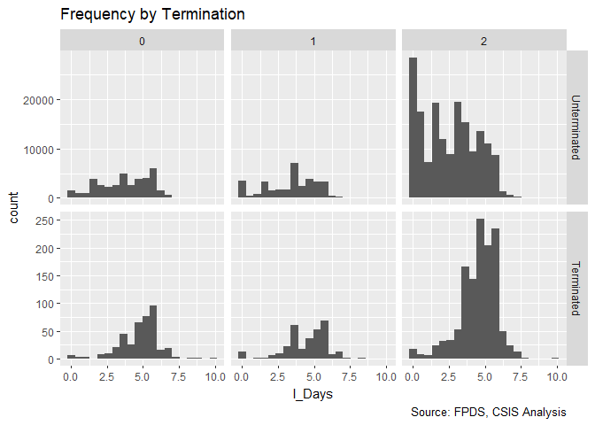

```r
#Frequency Plot
ggplot(data=subset(Term_smp,!is.na(n_Comp)),
       aes(x=l_Days))+geom_histogram(bins=20)+facet_grid(Term~n_Comp,scales="free_y")+
  labs(title="Frequency by Termination",
          caption="Source: FPDS, CSIS Analysis")
```

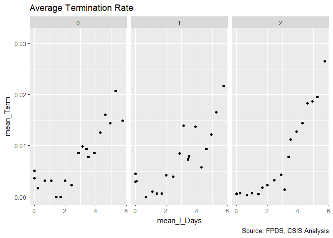

```r
#Plot the percent terminated across duration and competition
Term_smp$bin_Days_Comp<-bin_df(Term_smp,"l_Days")
ggplot(data=subset(Term_smp,!is.na(n_Comp)&!is.na(bin_Days_Comp)) %>%
  group_by(bin_Days_Comp,n_Comp) %>%
  summarise (mean_Term = mean(b_Term),
             mean_l_Days =mean(l_Days)),
       aes(y=mean_Term,x=mean_l_Days))+geom_point()+facet_wrap(~n_Comp)+facet_wrap(~n_Comp)+
  labs(title="Average Termination Rate",
          caption="Source: FPDS, CSIS Analysis")
```

```r
#Create the model
Term_02H <- glm (data=Term_smp,
                 b_Term ~n_Comp +
                   cl_Ceil + clsqr_Ceil + cl_Days+ clsqr_Days +
                   n_Comp:cl_Ceil  + cl_Ceil:cl_Days  + n_Comp:cl_Days, family=binomial(link="logit"))
display(Term_02H)
```

```
## glm(formula = b_Term ~ n_Comp + cl_Ceil + clsqr_Ceil + cl_Days +
##     clsqr_Days + n_Comp:cl_Ceil + cl_Ceil:cl_Days + n_Comp:cl_Days,
##     family = binomial(link = "logit"), data = Term_smp)
##                 coef.est coef.se
## (Intercept)     -5.09     0.08
## n_Comp          -0.15     0.05
## cl_Ceil          0.23     0.07
## clsqr_Ceil       0.03     0.02
## cl_Days          0.87     0.08
## clsqr_Days      -0.08     0.03
## n_Comp:cl_Ceil   0.04     0.03
## cl_Ceil:cl_Days -0.25     0.04
## n_Comp:cl_Days   0.23     0.04
## ---
##   n = 246889, k = 9
##   residual deviance = 21044.3, null deviance = 22986.9 (difference = 1942.7)
```

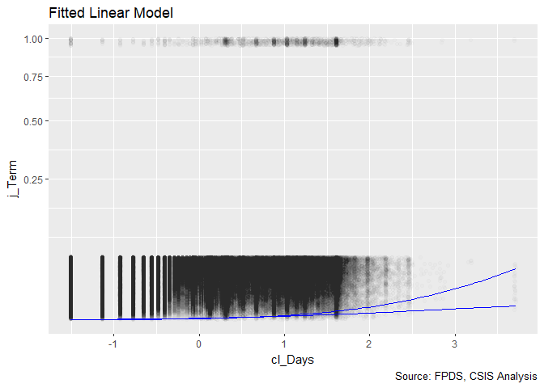

```r
Term_02H_curve<-function(x, Comp,Ceil){invlogit(
  cbind(1,Comp,Ceil,Ceil^2,x,x^2,
        Comp*Ceil,x*Ceil,x*Comp) %*%  coef(Term_02H))}

#Competition curves
fitted_term_model(Term_smp,"cl_Days") + stat_function(fun = Term_02H_curve,
                             args=list(Comp=0,Ceil=0),color="blue")+
  stat_function(fun = Term_02H_curve,
                             args=list(Comp=2,Ceil=0),color="blue")
```

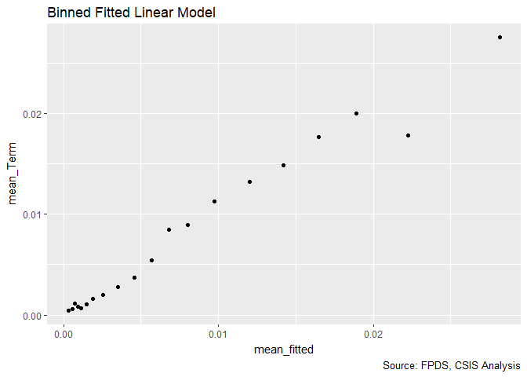

```r
#Plot the fitted values vs actual results
binned_fitted_versus_residuals(Term_02G)
```

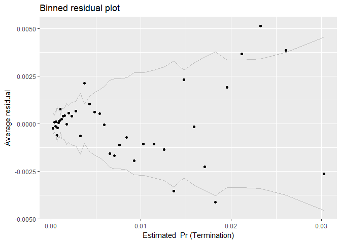

```r
#Plot residuals versus fitted
residuals_term_plot(Term_02G)+
  labs(x="Estimated  Pr (Termination)")
```

```r
# residuals_term_plot(Term_02F,"cl_days")+
#   labs(x="Centered Log(Days)")
```

The interaction of competition and duration is significant in itself and also has interesting consequences for other variables, notably boosting the cooeficient for ceiling and reducing the coefficient for duration. Competed contracts have a greater coefficient for termination. For short duration contracts, competition has a negative and significant coefficient but for long duration the relationship reverses itself. This would be consistent with the benefits of competition fading as the competition slipped further into the past. Unfortunately the residuals still show questionable patterns that merit continued observation.

## Contract Vehicle

Our dataset includes both stand alone contract awards and task orders that are under larger indefinite delivery vehilces (IDVs).

### Model 03A: Single-Award, Multi-Award, and Other Indefinite Delivery Vehicles

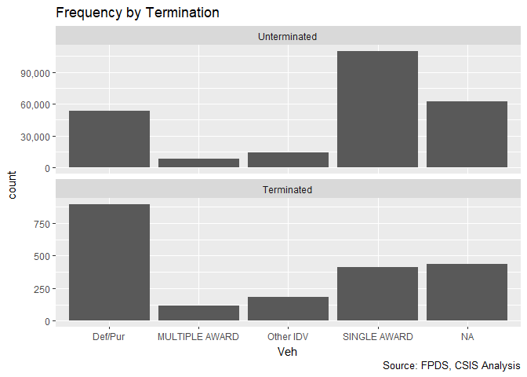

```r
#Frequency Plot
freq_discrete_term_plot(Term_smp,"Veh")
```

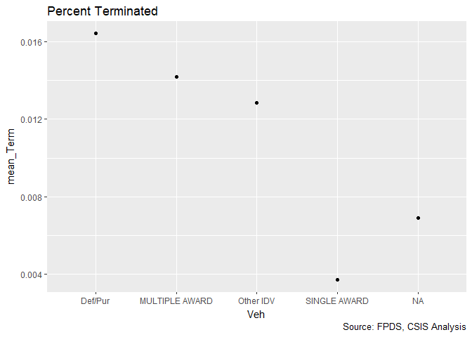

```r
#Percent Terminated Plot
discrete_percent_term_plot(Term_smp,"Veh")
```

```r
#Create the model
Term_03A <- glm (data=Term_smp,
                 b_Term ~n_Comp +
                   cl_Ceil + clsqr_Ceil + cl_Days+ clsqr_Days +
                   SIDV + MIDV + OIDV +
                   n_Comp:cl_Ceil  + cl_Ceil:cl_Days  + n_Comp:cl_Days, family=binomial(link="logit"))
display(Term_03A)
```

```
## glm(formula = b_Term ~ n_Comp + cl_Ceil + clsqr_Ceil + cl_Days +
##     clsqr_Days + SIDV + MIDV + OIDV + n_Comp:cl_Ceil + cl_Ceil:cl_Days +
##     n_Comp:cl_Days, family = binomial(link = "logit"), data = Term_smp)
##                 coef.est coef.se
## (Intercept)     -4.73     0.09
## n_Comp          -0.14     0.05
## cl_Ceil          0.11     0.08
## clsqr_Ceil       0.02     0.02
## cl_Days          0.66     0.08
## clsqr_Days       0.01     0.03
## SIDV            -0.92     0.07
## MIDV            -0.31     0.11
## OIDV            -0.14     0.08
## n_Comp:cl_Ceil   0.10     0.04
## cl_Ceil:cl_Days -0.12     0.05
## n_Comp:cl_Days   0.14     0.05
## ---
##   n = 184080, k = 12
##   residual deviance = 16307.3, null deviance = 17819.6 (difference = 1512.3)
```

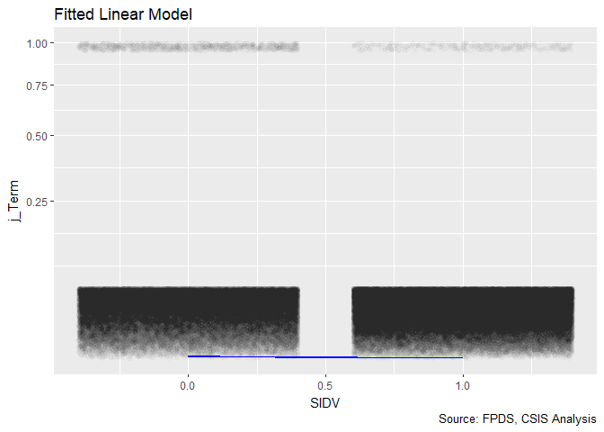

```r
#Plot the model and Vehicle for SIDV
Term_03A_SIDV_curve<-function(x, Comp,Ceil,Days,MIDV,OIDV){invlogit(
  cbind(1,Comp,Ceil,Ceil^2,Days,Days^2,x,MIDV,OIDV,
        Comp*Ceil,Days*Ceil,Days*Comp) %*%  coef(Term_03A))}

#Competition curves
discrete_fitted_term_model(Term_smp,"SIDV") +
  stat_function(fun = Term_03A_SIDV_curve,
                             args=list(Comp=0,Ceil=0,Days=0,
                                       MIDV=0,OIDV=0),color="blue")+
  stat_function(fun = Term_03A_SIDV_curve,
                             args=list(Comp=2,Ceil=0,Days=0,
                                       MIDV=0,OIDV=0),color="blue")
```

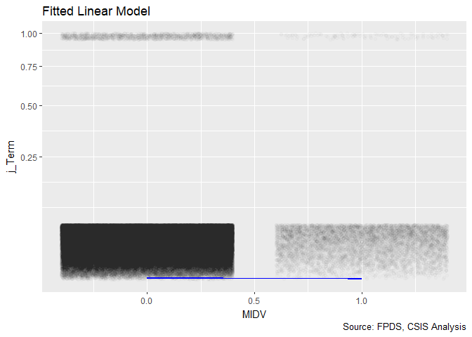

```r
Term_03A_MIDV_curve<-function(x, Comp,Ceil,Days,SIDV,OIDV){invlogit(
  cbind(1,Comp,Ceil,Ceil^2,Days,Days^2,SIDV,x,OIDV,
        Comp*Ceil,Days*Ceil,Days*Comp) %*%  coef(Term_03A))}

#Plot the model and Vehicle for MIDV
#Competition curves
discrete_fitted_term_model(Term_smp,"MIDV") +
  stat_function(fun = Term_03A_MIDV_curve,
                             args=list(Comp=0,Ceil=0,Days=0,
                                       SIDV=0,OIDV=0),color="blue")+
  stat_function(fun = Term_03A_MIDV_curve,
                             args=list(Comp=2,Ceil=0,Days=0,
                                       SIDV=0,OIDV=0),color="blue")
```

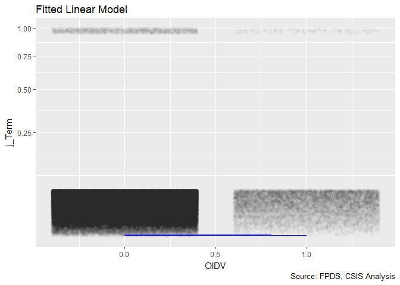

```r
Term_03A_OIDV_curve<-function(x, Comp,Ceil,Days,SIDV,MIDV){invlogit(
  cbind(1,Comp,Ceil,Ceil^2,Days,Days^2,SIDV,MIDV,x,
        Comp*Ceil,Days*Ceil,Days*Comp) %*%  coef(Term_03A))}

#Plot the model and Vehicle for OIDV
#Competition curves
discrete_fitted_term_model(Term_smp,"OIDV") +
  stat_function(fun = Term_03A_OIDV_curve,
                             args=list(Comp=0,Ceil=0,Days=0,
                                       SIDV=0,MIDV=0),color="blue")+
  stat_function(fun = Term_03A_OIDV_curve,
                             args=list(Comp=2,Ceil=0,Days=0,
                                       SIDV=0,MIDV=0),color="blue")
```

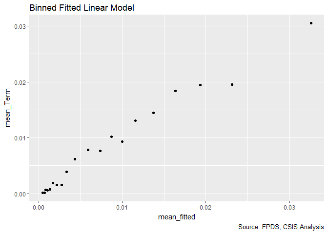

```r
#Plot the fitted values vs actual results
binned_fitted_versus_residuals(Term_03A)
```

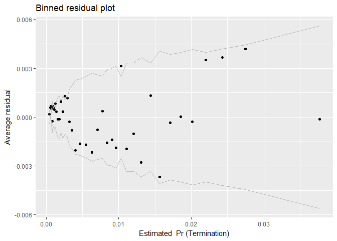

```r
#Plot residuals versus fitted
residuals_term_plot(Term_03A)+
  labs(x="Estimated  Pr (Termination)")
```

```r
# residuals_term_plot(Term_02F,"cl_days")+
#   labs(x="Centered Log(Days)")
```

This may reflect that the Ceiling and Days entries reflect only the task order and not the larger contract. The next step is to check the intersections with ceiling.

### Model 03B: Vehicle and Contract Duration

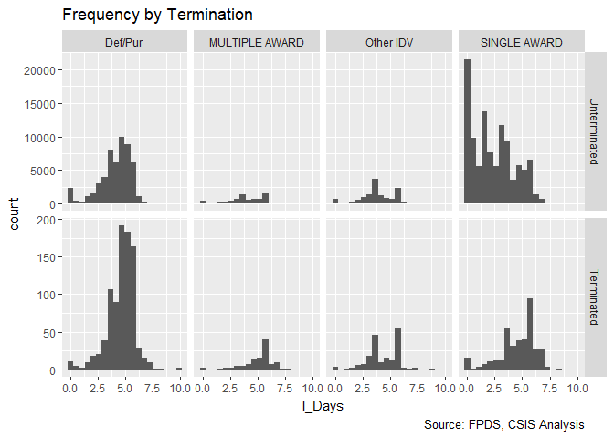

```r
#Frequency Plot
ggplot(data=subset(Term_smp,!is.na(Veh)),
       aes(x=l_Days))+geom_histogram(bins=20)+facet_grid(Term~Veh,scales="free_y")+
  labs(title="Frequency by Termination",
          caption="Source: FPDS, CSIS Analysis")
```

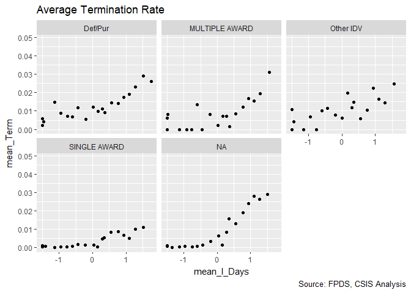

```r
#Plot the percent terminated across duration and competition
Term_smp$bin_Days_Veh<-bin_df(Term_smp,"l_Days","Veh")
ggplot(data=subset(Term_smp,!is.na(n_Comp)&!is.na(bin_Days_Comp)) %>%
  group_by(bin_Days_Veh,Veh) %>%
  summarise (mean_Term = mean(b_Term),
             mean_l_Days =mean(cl_Days)),
       aes(y=mean_Term,x=mean_l_Days))+geom_point()+facet_wrap(~Veh)+
  labs(title="Average Termination Rate",
          caption="Source: FPDS, CSIS Analysis")
```

```r
#Create the model
Term_03B <- glm (data=Term_smp,
                 b_Term ~n_Comp +
                   cl_Ceil + clsqr_Ceil + cl_Days+ clsqr_Days +
                   SIDV + MIDV + OIDV +
                   n_Comp:cl_Ceil  + cl_Ceil:cl_Days  + n_Comp:cl_Days +
                 SIDV:cl_Days+MIDV:cl_Days+OIDV:cl_Days, family=binomial(link="logit"))
display(Term_03B)
```

```
## glm(formula = b_Term ~ n_Comp + cl_Ceil + clsqr_Ceil + cl_Days +
##     clsqr_Days + SIDV + MIDV + OIDV + n_Comp:cl_Ceil + cl_Ceil:cl_Days +
##     n_Comp:cl_Days + SIDV:cl_Days + MIDV:cl_Days + OIDV:cl_Days,
##     family = binomial(link = "logit"), data = Term_smp)
##                 coef.est coef.se
## (Intercept)     -4.66     0.09
## n_Comp          -0.03     0.06
## cl_Ceil          0.07     0.08
## clsqr_Ceil       0.03     0.02
## cl_Days          0.52     0.09
## clsqr_Days       0.04     0.03
## SIDV            -1.41     0.10
## MIDV            -0.79     0.22
## OIDV            -0.03     0.12
## n_Comp:cl_Ceil   0.10     0.04
## cl_Ceil:cl_Days -0.12     0.05
## n_Comp:cl_Days   0.06     0.05
## cl_Days:SIDV     0.52     0.08
## cl_Days:MIDV     0.44     0.16
## cl_Days:OIDV    -0.15     0.11
## ---
##   n = 184080, k = 15
##   residual deviance = 16251.7, null deviance = 17819.6 (difference = 1567.9)
```

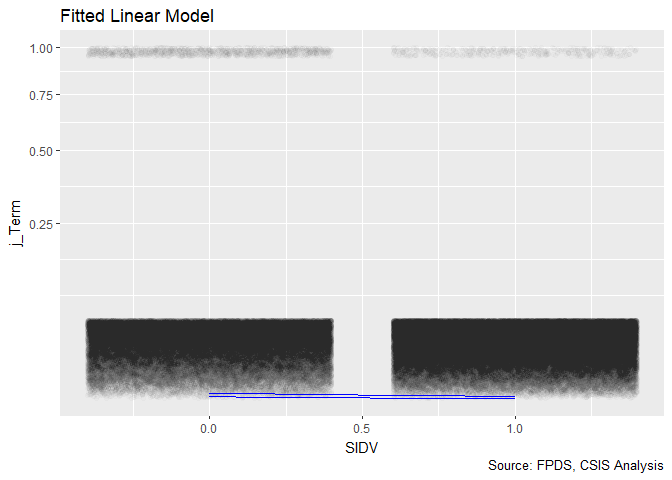

```r
# Plot the model and Vehicle for SIDV
Term_03B_SIDV_curve<-function(x, Comp,Ceil,Days,MIDV,OIDV){invlogit(
  cbind(1,Comp,Ceil,Ceil^2,Days,Days^2,x,MIDV,OIDV,
        Comp*Ceil,Days*Ceil,Days*Comp,
        Days*x,Days*MIDV,Days*OIDV) %*%  coef(Term_03B))}

#Duration curves
discrete_fitted_term_model(Term_smp,"SIDV") +
  stat_function(fun = Term_03B_SIDV_curve,
                             args=list(Comp=0,Ceil=0,Days=-1,
                                       MIDV=0,OIDV=0),color="blue")+
  stat_function(fun = Term_03B_SIDV_curve,
                             args=list(Comp=0,Ceil=0,Days=1,
                                       MIDV=0,OIDV=0),color="blue")
```

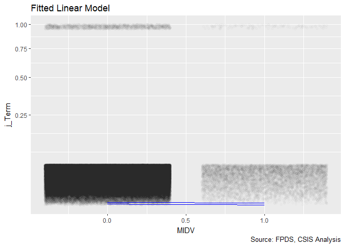

```r
Term_03B_MIDV_curve<-function(x, Comp,Ceil,Days,SIDV,OIDV){invlogit(
  cbind(1,Comp,Ceil,Ceil^2,Days,Days^2,SIDV,x,OIDV,
        Comp*Ceil,Days*Ceil,Days*Comp,
        Days*SIDV,Days*x,Days*OIDV) %*%  coef(Term_03B))}

#Plot the model and Vehicle for MIDV
#Duration Curves
discrete_fitted_term_model(Term_smp,"MIDV") +
  stat_function(fun = Term_03B_MIDV_curve,
                             args=list(Comp=0,Ceil=0,Days=-1,
                                       SIDV=0,OIDV=0),color="blue")+
  stat_function(fun = Term_03B_MIDV_curve,
                             args=list(Comp=0,Ceil=0,Days=1,
                                       SIDV=0,OIDV=0),color="blue")
```

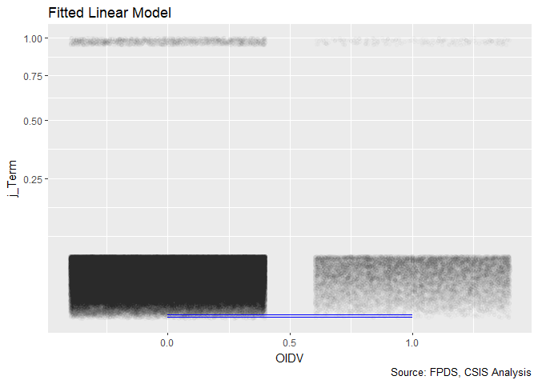

```r
Term_03B_OIDV_curve<-function(x, Comp,Ceil,Days,SIDV,MIDV){invlogit(
  cbind(1,Comp,Ceil,Ceil^2,Days,Days^2,SIDV,MIDV,x,
        Comp*Ceil,Days*Ceil,Days*Comp,
        Days*SIDV,Days*MIDV,Days*x) %*%  coef(Term_03B))}

#Plot the model and Vehicle for OIDV
#Duration curves
discrete_fitted_term_model(Term_smp,"OIDV") +
  stat_function(fun = Term_03B_OIDV_curve,
                             args=list(Comp=0,Ceil=0,Days=-1,
                                       SIDV=0,MIDV=0),color="blue")+
  stat_function(fun = Term_03B_OIDV_curve,
                             args=list(Comp=0,Ceil=0,Days=1,
                                       SIDV=0,MIDV=0),color="blue")
```

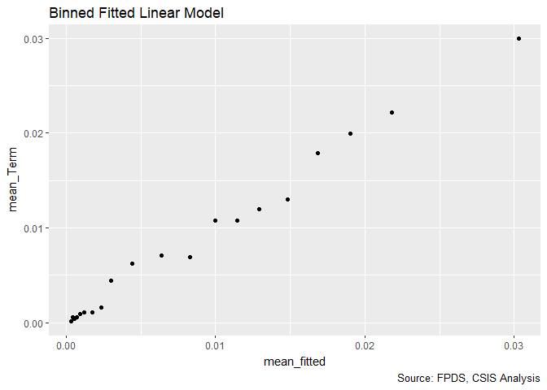

```r
#Plot the fitted values vs actual results
binned_fitted_versus_residuals(Term_03B)
```

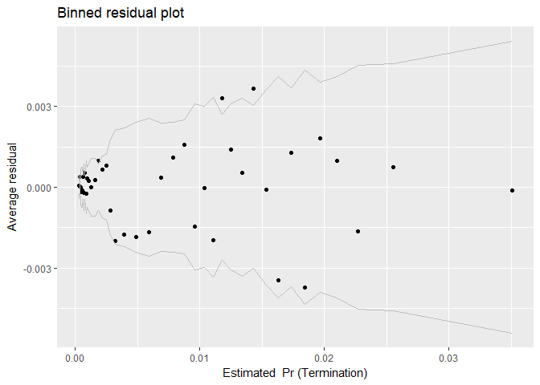

```r
#Plot residuals versus fittedO
residuals_term_plot(Term_03B)+
  labs(x="Estimated  Pr (Termination)")
```

```r
# residuals_term_plot(Term_02F,"cl_days")+
#   labs(x="Centered Log(Days)")
```

### Model 03C: Vehicle and Competition

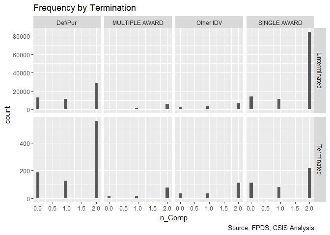

```r
#Frequency Plot
ggplot(data=subset(Term_smp,!is.na(Veh)),
       aes(x=n_Comp))+geom_histogram(bins=20)+facet_grid(Term~Veh,scales="free_y")+
  labs(title="Frequency by Termination",
          caption="Source: FPDS, CSIS Analysis")
```

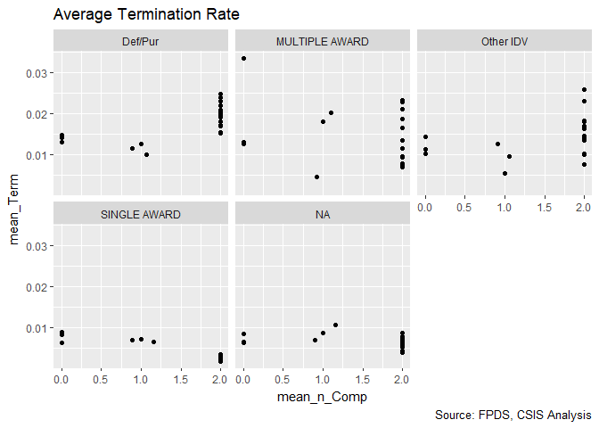

```r
#Plot the percent terminated across duration and competition
Term_smp$bin_n_Comp_Veh<-bin_df(Term_smp,"n_Comp","Veh")
ggplot(data=subset(Term_smp,!is.na(n_Comp)&!is.na(bin_n_Comp_Veh)) %>%
  group_by(bin_n_Comp_Veh,Veh) %>%
  summarise (mean_Term = mean(b_Term),
             mean_n_Comp =mean(n_Comp)),
       aes(y=mean_Term,x=mean_n_Comp))+geom_point()+facet_wrap(~Veh)+
  labs(title="Average Termination Rate",
          caption="Source: FPDS, CSIS Analysis")
```

```r
#Create the model
Term_03C <- glm (data=Term_smp,
                 b_Term ~n_Comp +
                   cl_Ceil + clsqr_Ceil + cl_Days+ clsqr_Days +
                   SIDV + MIDV + OIDV +
                   n_Comp:cl_Ceil  + cl_Ceil:cl_Days  + n_Comp:cl_Days +
                 SIDV:cl_Days+MIDV:cl_Days+OIDV:cl_Days +
                   SIDV:n_Comp+MIDV:n_Comp+OIDV:n_Comp , family=binomial(link="logit"))
display(Term_03C)
```

```
## glm(formula = b_Term ~ n_Comp + cl_Ceil + clsqr_Ceil + cl_Days +
##     clsqr_Days + SIDV + MIDV + OIDV + n_Comp:cl_Ceil + cl_Ceil:cl_Days +
##     n_Comp:cl_Days + SIDV:cl_Days + MIDV:cl_Days + OIDV:cl_Days +
##     SIDV:n_Comp + MIDV:n_Comp + OIDV:n_Comp, family = binomial(link = "logit"),
##     data = Term_smp)
##                 coef.est coef.se
## (Intercept)     -4.73     0.10
## n_Comp           0.03     0.06
## cl_Ceil          0.04     0.08
## clsqr_Ceil       0.02     0.02
## cl_Days          0.46     0.09
## clsqr_Days       0.05     0.03
## SIDV            -0.91     0.15
## MIDV            -0.23     0.31
## OIDV            -0.20     0.20
## n_Comp:cl_Ceil   0.13     0.04
## cl_Ceil:cl_Days -0.11     0.05
## n_Comp:cl_Days   0.09     0.05
## cl_Days:SIDV     0.46     0.08
## cl_Days:MIDV     0.40     0.16
## cl_Days:OIDV    -0.11     0.11
## n_Comp:SIDV     -0.34     0.07
## n_Comp:MIDV     -0.35     0.14
## n_Comp:OIDV      0.11     0.11
## ---
##   n = 184080, k = 18
##   residual deviance = 16224.0, null deviance = 17819.6 (difference = 1595.6)
```

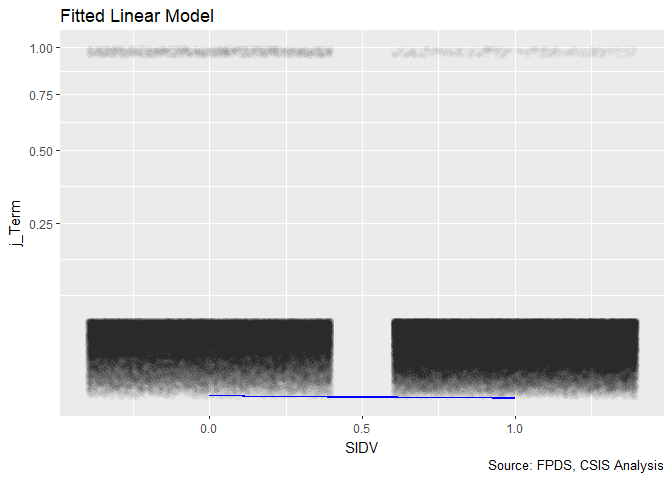

```r
# Plot the model and Vehicle for SIDV
Term_03C_SIDV_curve<-function(x, Comp,Ceil,Days,MIDV,OIDV){invlogit(
  cbind(1,Comp,Ceil,Ceil^2,Days,Days^2,x,MIDV,OIDV,
        Comp*Ceil,Days*Ceil,Days*Comp,
        Days*x,Days*MIDV,Days*OIDV,
        Comp*x,Comp*MIDV,Comp*OIDV) %*%  coef(Term_03C))}

#Competition curves
discrete_fitted_term_model(Term_smp,"SIDV") +
  stat_function(fun = Term_03C_SIDV_curve,
                             args=list(Comp=0,Ceil=0,Days=0,
                                       MIDV=0,OIDV=0),color="blue")+
  stat_function(fun = Term_03C_SIDV_curve,
                             args=list(Comp=2,Ceil=0,Days=0,
                                       MIDV=0,OIDV=0),color="blue")
```

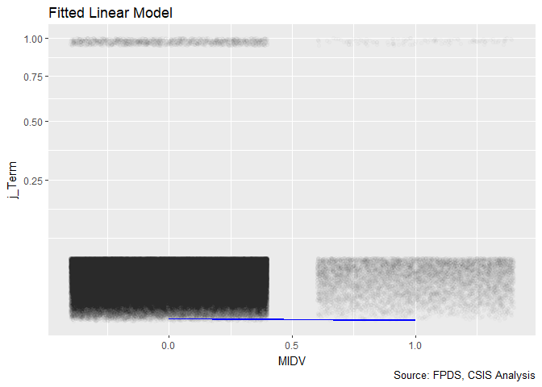

```r
Term_03C_MIDV_curve<-function(x, Comp,Ceil,Days,SIDV,OIDV){invlogit(
  cbind(1,Comp,Ceil,Ceil^2,Days,Days^2,SIDV,x,OIDV,
        Comp*Ceil,Days*Ceil,Days*Comp,
        Days*SIDV,Days*x,Days*OIDV,
        Comp*SIDV,Comp*x,Comp*OIDV) %*%  coef(Term_03C))}

#Plot the model and Vehicle for MIDV
#Competition Curves
discrete_fitted_term_model(Term_smp,"MIDV") +
  stat_function(fun = Term_03C_MIDV_curve,
                             args=list(Comp=0,Ceil=0,Days=0,
                                       SIDV=0,OIDV=0),color="blue")+
  stat_function(fun = Term_03C_MIDV_curve,
                             args=list(Comp=2,Ceil=0,Days=0,
                                       SIDV=0,OIDV=0),color="blue")
```

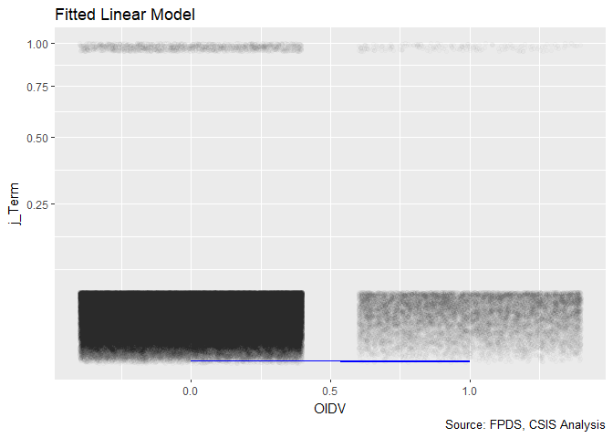

```r
Term_03C_OIDV_curve<-function(x, Comp,Ceil,Days,SIDV,MIDV){invlogit(
  cbind(1,Comp,Ceil,Ceil^2,Days,Days^2,SIDV,MIDV,x,
        Comp*Ceil,Days*Ceil,Days*Comp,
        Days*SIDV,Days*MIDV,Days*x,
        Comp*SIDV,Comp*MIDV,Comp*x) %*%  coef(Term_03C))}

#Plot the model and Vehicle for OIDV
#Competition curves
discrete_fitted_term_model(Term_smp,"OIDV") +
  stat_function(fun = Term_03C_OIDV_curve,
                             args=list(Comp=0,Ceil=0,Days=0,
                                       SIDV=0,MIDV=0),color="blue")+
  stat_function(fun = Term_03C_OIDV_curve,
                             args=list(Comp=2,Ceil=0,Days=0,
                                       SIDV=0,MIDV=0),color="blue")
```

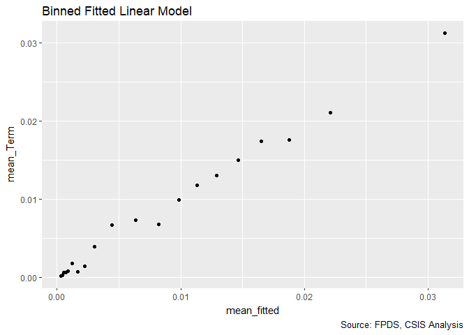

```r
#Plot the fitted values vs actual results
binned_fitted_versus_residuals(Term_03C)
```

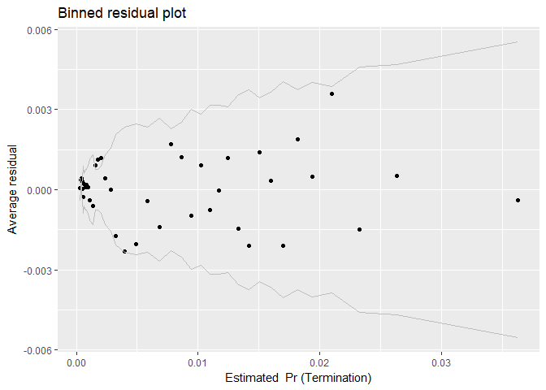

```r
#Plot residuals versus fittedO
residuals_term_plot(Term_03C)+
  labs(x="Estimated  Pr (Termination)")
```

```r
# residuals_term_plot(Term_02F,"cl_days")+
#   labs(x="Centered Log(Days)")
```

Interactions * For single-award IDVs, competition magnifies the lower termination coeffient. This is somewhat surprising, as competition reflects the competed status of the IDV, not the individual task order. Nonetheless, that rate appears to very much matter, and suggests that uncompeted IDVs lose some of their termination reduction correlation. * For multiple-award IDVs, competition also dampens the termination rate. This also magnificies the import of duration for multiple-award IDVs, which now can complete overcome the base termination coefficient of the vehicle. * Competition dampens the termination reduction coefficient for other IDVs. It is not significant, I am tempted to leave it out, though it may be appropriate to always leave in the triples.

### Model 03D: Any IDV and Contract ceiling

```r
# Term_03D <- glmer (data=Term_smp,
#                  b_Term ~ l_Ceil + l_Days + l_Ceil:l_Days +
#                    IDV + IDV:l_Days+
#                (1 | Who) + (1 | PSR_What) + (1 | StartFY), family=binomial(link="logit"))
# display(Term_03D)
```

The results a dramatic, longer IDVs do face higher risks of termination. That said, the termination risk reduction for all IDVs has grown even further as a result, so even longer task orders may not face greater termination risks than comparable contract awards. With this addition, the intersection of contract ceiling and maximum duration is no longer significant, the next step will be testing its removal from the equation.

The lower rate of task order termination did not prove to be relevant to contract ceiling. The next step is to see whether there is any relationship to maximum duration. Under this theory, the fact that IDVs make it simpler to do multiple short task orders could mask any risk when task order duratioN grows longer.

### Model 03E: Trimming the intersection of duration and ceiling

```r
# Term_03E <- glmer (data=Term_smp,
#                  b_Term ~ l_Ceil + l_Days +
#                    IDV + IDV:l_Days+
#                (1 | Who) + (1 | PSR_What) + (1 | StartFY), family=binomial(link="logit"))
# display(Term_03E)
```

The removal has little effect on the AIC or DIC but does simplify the model.

Subsequent steps will explore the difference between multiple-award IDVs, where the government can choose from a pre-qualified pool of vendors, and single-award IDVs, where the government only has one option.

## Type of Contract

### Model 13A: Fixed-Price Contracts

The next step adds a measure for whether the contract was cost-based or fixed-price. Prior CSIS research has found that fixed-price contracts do face a higher risk of termination across the board.

```r
# Term_13A <- glmer (data=Term_smp,
#                  b_Term ~ l_Ceil + l_Days +
#                    SIDV + MIDV + OIDV + SIDV:l_Days +
#                    n_Fixed +
#                (1 | Who) + (1 | PSR_What) + (1 | StartFY), family=binomial(link="logit"))
# display(Term_13A)
```

And fixed price contracts do indeed have a appreciably higher average termination rate. This does not improve the overall AIC of the model, but it captures another important dynamic and has a coefficient that greatly exceeds its standard error.

### Model 13B: Fixed-Price and Maximum Duration

Past CSIS research has found that fixed-price contracts do appear to be at higher risk if they have a longer maximum duration. Fixed-price contracting does require upfront estimation of likely costs, and thus a longer duration means more opportunity for changed circumstance.

```r
# Term_13B <- glmer (data=Term_smp,
#                   b_Term ~ l_Ceil + l_Days +
#                    SIDV + MIDV + OIDV + SIDV:l_Days +
#                    n_Fixed + l_Days:n_Fixed +
#                (1 | Who) + (1 | PSR_What) + (1 | StartFY), family=binomial(link="logit"))
# display(Term_13B)
```

The model failed to converge and the coefficient, while large, did not exceed the standard error. That said, it is worth noting that the sign went in the opposite direction from what was expected, with longer fixed-price contracts not being associated with disproprtionately higher terminations rates. Thus, the earlier finding is not replicated.

### Model 13C: Incentive Fees

In the performance of the defense acquisition system report, the benefits found were reduced cost overruns. That could help avoid terminations, but it’s an indirect connection at best.

```r
# Term_13C <- glmer (data=Term_smp,
#                   b_Term ~ l_Ceil + l_Days +
#                    SIDV + MIDV + OIDV + SIDV:l_Days +
#                    n_Fixed + nIncent +
#                (1 | Who) + (1 | PSR_What) + (1 | StartFY), family=binomial(link="logit"))
# display(Term_13C)
```

### Model 13D: Undefinitized Contract Awards

Undefinitized Contract Awards allow for quick action in situations where there is not time or information to establish all of a contracts properties at the time of signing. They have been found by the GAO and the Performance of the Defense Acquisition studies to contain notable risks, primarily relating to cost overruns. Will these risks also carry into terminations?

```r
#Run through stopped here
# Term3D <- glmer (data=Term_smp,
#                   b_Term ~ l_Ceil + l_Days +
#                    SIDV + MIDV + OIDV + SIDV:l_Days +
#                    n_Fixed  + n_UCA +
#                (1 | Who) + (1 | PSR_What) + (1 | StartFY), family=binomial(link="logit"))
# display(Term3D)
```

Use of UCA significantly increases risks of termination, well in excess of the error term. Interestingly, while this addition further reduceds the AIC and DIC of the model, it also increases the coefficient for fixed price contracts.

## Place of Performance

### Model 14A: Any International

```r
# Term4A <- glmer (data=Term_smp,
#                   b_Term ~ l_Ceil + l_Days +
#                    SIDV + MIDV + OIDV + SIDV:l_Days +
#                    n_Fixed  + n_UCA +
#                    nIntl +
#                (1 | Who) + (1 | PSR_What) + (1 | StartFY), family=binomial(link="logit"))
# display(Term4A)
```

International performance of contract proved to not be an effective predictor of contract termination. In addition, the model failed to converge. This variable will not be added.

## Competition Variables

### Model 15A: Competition

### Model 15C: Competition and Fixed Price

```r
# Term_02C <- glmer (data=Term_smp,b_Term ~ l_Ceil + l_Days +
#                    SIDV + MIDV + OIDV + SIDV:l_Days +
#                    n_Fixed  + n_UCA +
#                    cb_Comp + cb_Comp:n_Fixed +
#                (1 | Who) + (1 | PSR_What) + (1 | StartFY), family=binomial(link="logit"))
# display(Term_02C)
```

THese results are not sufficiently signficiant to justify inclusion, but the interaction between fixed price and competition is potentially interesting and suggests that the demographics of competed contrats may be one factor driving their increase in termination risk. Specifically, one possibility may be that competitive fixed-price contracts are at greater risk of aggressive bids that increase contract risk.

### Model 15D: Fixed Price and Number of Offers for Competed Contracts

```r
# Term_02D <- glmer (data=subset(Term_smp,cb_Comp==1),
#               b_Term ~ l_Ceil + l_Days +
#                 SIDV + MIDV + OIDV + SIDV:l_Days +
#                    n_Fixed  + n_UCA +  lOffer + lOffer:n_Fixed +
#                (1 | Who) + (1 | PSR_What) + (1 | StartFY), family=binomial(link="logit"))
# display(Term_02D)
```

Focusing again on only those contracts that were competed, there does not appear to be a relationship between fixed price contracting and the number of offers. This undercuts the idea that the competition dynamics can be explained as simply relating to aggressive bidding on fixed price contracts.

### Model 15E: Competition and Contract Ceiling

```r
# Term_15E <- glmer (data=Term_smp,
#                  b_Term ~ l_Ceil + l_Days +
#                    SIDV + MIDV + OIDV + SIDV:l_Days +
#                 n_Fixed  + n_UCA +
#                   cb_Comp + cb_Comp:l_Ceil +
#                (1 | Who) + (1 | PSR_What) + (1 | StartFY), family=binomial(link="logit"))
# display(Term_15E)
```

The coefficient for the interaction of Ceiling and Competition exceeds the standard error, but only minimally. The model also fails to converge, so we’ll leave out this interaction.

### Model 15F: Single-Award IDVs and Competition

The next step is to check interactions with the contract vehicles. Each has a slightly different approach to competition. For example, the competition for a Single-Award IDV happens at the start of the IDV, after that, contracts awarded through that vehicle go to that single winning vendor.

```r
# Term_15F <- glmer (data=Term_smp,
#                 b_Term ~ l_Ceil + l_Days +
#                 SIDV + MIDV + OIDV + SIDV:l_Days +
#                 n_Fixed  + n_UCA +
#                 cb_Comp + cb_Comp:SIDV +
#                (1 | Who) + (1 | PSR_What) + (1 | StartFY), family=binomial(link="logit"))
# display(Term_15F)
#
```

That result proved stronger than expected and does seem to show that that competed IDVs do have a lower average risk of terminations. However, the model failed to converge.

Next, we’ll check the same relationship, but with number of offers instead.

### Model 15G: Single-Award IDVs and Number of Offers

```r
# Term_15G <- glmer (data=Term_smp,
#                  b_Term ~ l_Ceil + l_Days +
#                 SIDV + MIDV + OIDV + SIDV:l_Days +
#                 n_Fixed  + n_UCA +
#                 lOffer + lOffer:SIDV +
#                (1 | Who) + (1 | PSR_What) + (1 | StartFY), family=binomial(link="logit"))
# display(Term_15G)
```

The model likewise failed to converge with number of offers and the number of offers proved a less powerful interaction variable than extent of competition.

### Model 15H: Multiple-Award IDVs and Competition

```r
# Term_15H <- glmer (data=Term_smp,
#                  b_Term ~ l_Ceil + l_Days +
#                 SIDV + MIDV + OIDV + SIDV:l_Days +
#                 n_Fixed  + n_UCA +
#                 cb_Comp + cb_Comp:MIDV +
#                (1 | Who) + (1 | PSR_What) + (1 | StartFY), family=binomial(link="logit"))
# display(Term_15H)
# nrow(Term_smp[!is.na(Term_smp$l_Ceil) &
#                 !is.na(Term_smp$lDays) &
#                 !is.na(Term_smp$IDV) &
#               !is.na(Term_smp$nUCA) &
#                 !is.na(Term_smp$Fixed)
#                 !is.na(Term_smp$cb_Comp),])
```

### Model 15I: Multiple-Award IDVs and Number of Offers

```r
# Term_15I <- glmer (data=Term_smp,
#                  b_Term ~ l_Ceil + l_Days +
#                 SIDV + MIDV + OIDV + SIDV:l_Days +
#                 n_Fixed  + n_UCA +
#                 lOffer + MIDV:lOffer +
#                (1 | Who) + (1 | PSR_What) + (1 | StartFY), family=binomial(link="logit"))
# display(Term_15I)
```

### Model 15J: Other IDVs and Competition

Unlike the existance of competition, having more offers does not have the same dramatic relationship with multi-award IDVs that it does with competition. This does raise the question as to whether the long tail of high numbers of offers might be undercutting the relationship. However, for now, we will stick with competition.

```r
# Term_15J <- glmer (data=Term_smp,
#                  b_Term ~ l_Ceil + l_Days +
#                 SIDV + MIDV + OIDV + SIDV:l_Days +
#                 n_Fixed  + n_UCA +
#                 cb_Comp + cb_Comp:MIDV + cb_Comp:OIDV +
#                (1 | Who) + (1 | PSR_What) + (1 | StartFY), family=binomial(link="logit"))
# display(Term_15J)
```

Competition and Other IDVs only slightly exceeds the standard error.

## Selection: Model 05H

```r
# TermModel<-Term_15H
# display(Term_15H)
```